[figure not shown]

ET-16

Steering Satellite Switch

ENTERTAINMENT

11.Steering Satellite Switch

A: REMOVAL

CAUTION:

1) Set the tire to the straight-ahead position.

NOTE:

For models other than STI model, disconnect the ground terminal from battery sensor.

3) Remove the driver’s airbag module. <Ref. to AB-33, REMOVAL, Driver’s Airbag Module.>

4) Remove the steering wheel. <Ref. to PS-16, REMOVAL, Steering Wheel.>

5) Remove the satellite switch assembly. <Ref. to PS-17, DISASSEMBLY, Steering Wheel.>

B: INSTALLATION

CAUTION:

• Do not allow harness and connectors to interfere or get tangled up with other parts.

• Make sure that the steering roll connector is not turned from the original position.

1) Install the satellite switch assembly.

2) Align the center position of the steering roll connector. <Ref. to AB-64, ADJUSTMENT, Roll Connector.>

3) Install the steering wheel.

Tightening torque:

39 N·m (4.0 kgf-m, 28.8 ft-lb)

Clearance:

Between cover assembly - column and steering wheel: 4 — 6 mm (0.16 — 0.24 in)

4) Install the driver’s airbag module. <Ref. to AB-34, INSTALLATION, Driver’s Airbag Module.>

5) Connect the battery ground terminal. <Ref. to NT-5, BATTERY, NOTE, Note.>

NOTE:

For models other than STI model, connect the ground terminal to battery sensor.

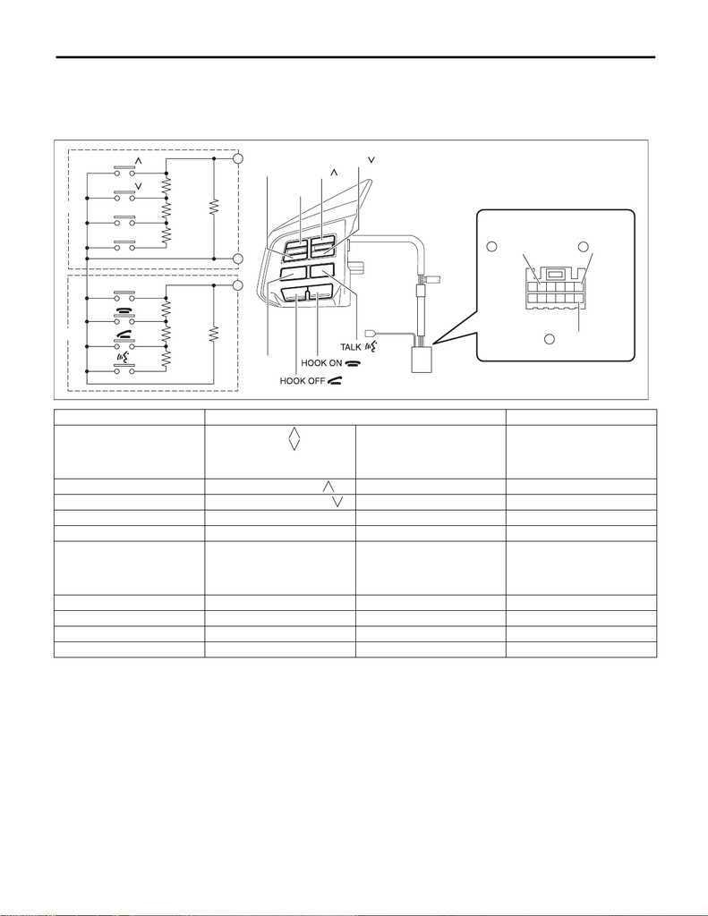

ET-17

Steering Satellite Switch

ENTERTAINMENT

C: INSPECTION

1) Measure the resistance between connector terminals.

Preparation tool:

Circuit tester

2) If the result of the measurement is not at the standard, replace the satellite switch assembly.

Terminal No. Inspection conditions Standard

VOL (+)

VOL (–)

A circuit is all OFF. Approx. 100 kΩ

6 — 2 VOL (+) ON Approx. 1000 Ω

6 — 2 VOL (–) ON Approx. 3110 Ω

12 — 2

MODE

HOOK ON

HOOK OFF

TALK

B circuit is all OFF. Approx. 100 kΩ

12 — 2 MODE ON Less than 1 Ω

12 — 2 HOOK ON ON Approx. 330 Ω

12 — 2 HOOK OFF ON Approx. 1000 Ω

12 — 2 TALK ON Approx. 3110 Ω

ET-00793

VOL +

VOL -

SEEK

12

AUDIO +

AUDIO GND

12

6

7

2

1

6

12

2

B

A

2

VOL -

MODE

SEEK

SEEK